# (PSL) Coding Assignment 3

Jake Goodman (Net ID: jakeg5) & Michael McClanahan (Net ID: mjm31)

Fall 2021

## Team Member Contribution

Jake Goodman (Net ID: jakeg5) completed Part I of the coding assignment and organized code, files and (Part I) results for the assignment.

Michael McClanahan (Net ID: mjm31) completed Part II and submitted the coding assignment on Coursera.

```r
set.seed(6379)
```

## Part I: Select optimal span for `loess`

### Defining the functions

#### `lo.lev` Function

```r
lo.lev = function(x1, sp){
  # x1: n-by-1 feature vector
  # sp: a numerical value for "span"

    ##############################################
  # YOUR CODE: Compute the diagonal entries of the
  #            smoother matrix S and
  #            store it in a vector "lev"
  # Tip: check how we compute the smoother matrix
  #      for smoothing spline models
  ##############################################
  n = length(x1);
  lev = rep(0, n)
  A = matrix(0, n, n)

  for(i in 1:n){
    y1 = rep(0,n)
    y1[i] = 1
    yi = loess(y1 ~ x1, control = lo_ct, span = sp)$fitted
    A[,i]= yi
  }



  # get the diagonal entries of the smoother matrix, which is what we'll return
  lev = diag((A+t(A))/2)

  return(lev)
}
```

#### `onestep_CV` Function

```r
onestep_CV <- function(x1, y1, sp){

  ##############################################
  #  YOUR CODE:
  #  1) Fit a loess model y1 ~ x1 with span = sp, and extract
  #     the corresponding residual vector
  #  2) Call lo.lev to obtain the diagonal entries of S
  #  3) Compute LOO-CV and GCV using formula from lecture notes
  #    [lec_W5_NonlinearRegression.pdf] page 33.
  ##############################################
  n = length(x1)

  # fit a loess model and extract the residuals
  resid = loess(y1 ~ x1, control = lo_ct, span = sp)$residuals

  # call lo.lev and store result in s
  s = lo.lev(x1, sp)

  cv = sum(((resid)/(1-s))^2)/n

  gcv = sum((resid)^2)/(1-sum(s)/n)^2/n

  return(list(cv = cv, gcv = gcv))
}
```

#### `myCV` Function

```r
myCV <- function(x1, y1, span){
  # x1: feature vector of length n
  # y1: response vector of length n
  # span: a sequence of values for "span"

  m = length(span)
  cv = rep(0, m)
  gcv = rep(0, m)

  for(i in 1:m){
    tmp = onestep_CV(x1, y1, span[i])
    cv[i] = tmp$cv
    gcv[i] = tmp$gcv
  }
  return(list(cv = cv, gcv = gcv))
}
```

### Testing the functions

Read in the data

```r
mydata = read.csv("Coding3_Data.csv")
```

Output the dimensions of the dataset

```r
dim(mydata)
```

```
## [1] 30  2
```

Plot the data present in `Coding3_Data.csv`

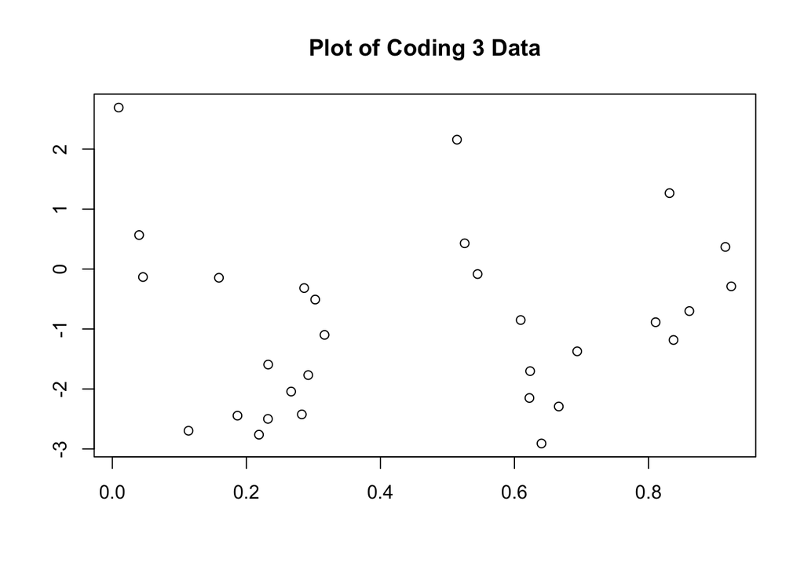

```r
plot(mydata$x, mydata$y,main = "Plot of Coding 3 Data", xlab="", ylab="")
```

Make `lo_ct` a global variable so it can easily be passed in the calls to `loess`

```r
lo_ct = loess.control(surface = "direct")
```

Create `span1` which will be the sequence of span values to be passed in through the various functions

```r
span1 = seq(from = 0.2, by = 0.05, length = 15 )
```

Call the `myCV` function which will compute the corresponding LOO_CV and GCV values

```r
cv.out = myCV(mydata$x, mydata$y, span1)
```

### Results printed out

```r
myout = data.frame(CV = cv.out$cv,
                   GCV = cv.out$gcv,
                   span = span1)
myout
```

| CV | GCV | span |
| --- | --- | --- |
| 12.416167 | 2.109088 | 0.20 |
| 2.241351 | 1.489063 | 0.25 |
| 1.502957 | 1.190075 | 0.30 |
| 1.302611 | 1.155223 | 0.35 |
| 1.223215 | 1.081272 | 0.40 |
| 1.173550 | 1.046493 | 0.45 |
| 1.121463 | 1.016964 | 0.50 |
| 1.166369 | 1.105829 | 0.55 |
| 1.172145 | 1.112322 | 0.60 |
| 1.228412 | 1.158067 | 0.65 |

[output cut: 5 more lines]

The results from the above table appear to exactly match the output provided in the [sample code](https://liangfgithub.github.io/F21/Coding3_Part_I_SampleCode_F21.html), which lets us feel confident about the functions we defined

```r
myout$span[myout$GCV == min(myout$GCV)]
```

```
## [1] 0.5
```

Similar to the sample code results, we see above that the 0.50 span value produced the lowest GCV value

```r
myout$span[myout$CV == min(myout$CV)]
```

```
## [1] 0.5
```

Similar to the sample code results, we see above that the 0.50 span value produced the lowest LOO-CV value

### Fitted curve plot

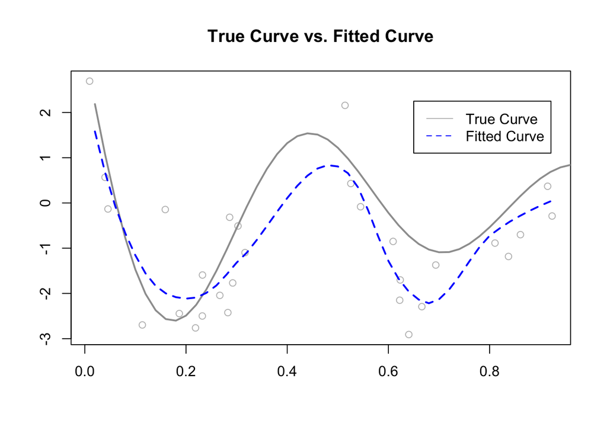

```r
spangcv.min = 0.5
plot(mydata$x, mydata$y, main = "True Curve vs. Fitted Curve", xlab="", ylab="", col="gray");
fx = 1:50/50;
fy = sin(12*(fx+0.2))/(fx+0.2)
lines(fx, fy, col=8, lwd=2);

f = loess(y ~ x, mydata, span = spangcv.min)
lines(fx, predict(f, data.frame(x = fx), surface = "direct"),
      lty=2, lwd=2, col="blue")
legend(0.65, 2.25, legend=c("True Curve","Fitted Curve"),
       col=c("gray","blue"), lty=1:2)
```

## Part II: Clustering time series